# Analysis of diseases transmission in the London underground system

2645930

2024-11-29

# 1.Introduction

The covid-19 pandemic has caused a great impact on the society, especially in the public transport system. It has changed how we view public transportation systems and their role in disease transmission. So it is important to study the infectious diseases spreading mechanism. And the idea of the report comes from the necessity of predicting the disease transmission. Among a large quantities of analysed objects, I focus on analysing the London underground system, because it is one of the busiest public transportation systems in the world, providing larger sample size and more comprehensive dataset. The London underground, where millions of passengers commute daily, presents an ideal case for studying disease spread in urban transit networks.

Previous researches have demonstrated that the network and flux information are enough to predict the dynamics and spread between cities (Brockmann and Helbing, 2013). This research extends their methodology to the smaller system - an urban subway system. Therefore, the aim of my report is to use the similar model to predict the spread of infectious diseases in the underground. The study is to find out which stations will be affected first, whether these stations have spatial clustering, and whether the government can control the spread by focusing on some specific areas.

The first part of my work is data collection and pre-processing. I collect the station location data, passenger flows, network connectivity information, and then filter these data for further process. Then I choose the model for analysis and create the network. After that, I analyse the network by calculating the effective distance, using it to obtain the closeness centrality, and finally identify the key stations. In the final part, I use Moran’s I to check for clustering of rapidly infected stations.

# 2. Methods

## 2.1 Datasets

London boroughs: I use the 2023 map vector of the city London Boroughs, which is provided by the institution Cartography Vectors to graph boundaries.

London tube stations location: this includes station’s latitude and longitude coordinates based on WGS84, and the Ordnance Survey coordinates based on OSGB36. In this report, I choose to use the WGS84 coordinates for the analysis and map.

London Underground System: The TFL made available the relevant information of tube stations. So I collect the data including connections(origin and destination), flows (number of passengers traveling between two stations), and population (number of passengers entering the system at each station). The graph being analysed represents this system as a network, which is made up of 399 nodes(stations) and 61474 different links(lines).

## 2.2 Model

Brockmann and Helbing (2013) introduced a network model to study the transmission of H1N1 flu and SARS between districts. They found that the complex system can be simply analysed by using the effective distance (defined by human mobility) rather than by the geographic distance, because the disease arrival time in the cities is only related to the effective distance to the Initial Outbreak Location (IOL). Therefore, I use flows instead of geographical distance for analysis.

Basic variables: w_ji:The weight w_ji represents the flux-fraction of travelers from node j to i, w_ji = F_ji/F_i, where the F_ji quantify direct underground traffic (flows), and F_i is the total number of passengers of station i (population). d_ji:The effective distance from node j to a connected node i is defined as d_ji = 1-log(w_ji).

Dijkstra’s algorithm: It’s a model to find the shortest path from one node (source node) to all other nodes in the graph, and generate a shortest path tree. This algorithm is based on the weight of the edges, which is the effective distance in my research. The algorithm first selects the node with the smallest distance iteratively, and updates the shortest paths to its neighbors until all nodes have been visited.

Arrival time and Closeness centrality: Closeness centrality formula is give by Newman and M. E. J.(2018). It is C_i^(k) = (n-1) / ∑_j D_ji^(k), where n-1 is the number of neighbors that reach node i, and D_ji^(k) is the shortest path from node j to i. According to Jorge L. B. et al.(2023), the arrival time of disease increases linearly with the average closeness centrality rank posiotion of the node. It indicates that if the centrality value is higher, the arrival time will be shorter, and the node will be affected faster.

Moran’s I: Moran’s I test is used to determine whether a dataset has spatial autocorrelation. The test statistic is calculated as I = n * (Σ_i Σ_j w_ij * z_i * z_j) / (Σ_i z_i^2), in this formula, z_i is the standardized value of the variable at location i, w_ij is the spatial weight between locations i and j, and n is the number of locations. The result of the test ranges from -1 to 1, where positive value means positive spatial autocorrelation, negative value means negative spatial autocorrelation, and value close to 0 means no spatial autocorrelation. The p-value is used to determine the significance of the test statistic, where a p-value less than 0.05 indicates significant spatial autocorrelation.

# 3. Analysis and results

## 3.1 Map of london with stations and boroughs

First, import some basic libraries. Here the library *shiny* is not used, because it is not available for knitting a html document.

```r
library(sf)
library(leaflet)
library(dplyr)
library(purrr)
library(tidyr)
library(knitr)
library(igraph)
library(spdep)
library(tmap)
```

The analysis begins with importing two essential datasets. I read the data and transform the coordinate system to WGS84, making sure the data use the same system for mapping. WGS84 is standard for GPS and web mapping. Libraries like `leaflet` use this system by default, so it can deduce the calculation and data processing steps. Overall, this standardization ensures consistent spatial operations and visualization throughout the analysis.

```r
london_borders <- st_read("london-boroughs_1179.geojson") %>%
    st_transform(4326) # transform to geometry for mapping
stations_df <- read.csv("London stations.csv")
stations_sf <- st_as_sf(stations_df,
                       coords = c("Longitude", "Latitude"),
                       crs = 4326) #use WGS84

# Associate station with the located administrative district
stations_with_borough <- st_join(stations_sf, london_borders)

# Create stations data frame with coordinates
stations_data <- stations_with_borough %>%
    mutate(
        longitude = unlist(map(geometry, 1)),
        latitude = unlist(map(geometry, 2))
    ) %>%
    st_drop_geometry()

colnames(stations_data) # check if the columns name is right
```

```
##  [1] "Station"           "OS.X"              "OS.Y"
##  [4] "Zone"              "Postcode"          "id"
##  [7] "name"              "code"              "area_hectares"
## [10] "inner_statistical" "longitude"         "latitude"
```

Now the `stations_data` has the coordinate and belonging borough that I need, so I can select the stations in the same district, and cluster them when zoomed out. The final result will show on an interactive map. This visualization way shows the overall distribution characteristics as well as maintaining the ability to view specific information details.

```r
# Create interactive map
map <- leaflet() %>%
    addTiles() %>%  # Add OpenStreetMap base layer
    setView(lng = -0.1276, lat = 51.5074, zoom = 10) %>%  # Set initial view to London center

    # draw a basic map of the border
    addPolygons(
        data = london_borders,
        fillColor = "lightblue",
        fillOpacity = 0.3,
        weight = 1,
        color = "blue",
        popup = ~name,
        highlightOptions = highlightOptions(
            weight = 2,
            color = "red",
            fillOpacity = 0.7,
            bringToFront = TRUE
        )
    ) %>%

    # Add station markers
    addMarkers(
        data = stations_data,
        lng = ~longitude,
        lat = ~latitude,
        popup = ~paste("<b>Station:</b>", Station,
                      "<br><b>Zone:</b>", Zone,
                      "<br><b>Coordinates:</b>",
                      round(longitude, 4), ",",
                      round(latitude, 4)),
                      # when clicking the station, it will show the station name, zone, and coordinates.
        clusterOptions = markerClusterOptions()
        #displays the stations cluster numbers in each borough
    )

# Display
map
```

[interactive chart not shown]

## 3.2 Calculate the effective distance between two points

The `flows_data` includes key information: connectivity between start and end stations, `flows`: the number of passengers traveling between them, `population`: population base (the number of passengers entering station). But `flows` and ``population` may not be numeric values, so I need to convert them to ensure the accuracy and reliability of the following calculation.

```r
# read connections and flows data
flows_data <- read.csv("london_flows.csv")

# pre-process data
pre_data <- flows_data %>%
  mutate(
    flows = as.numeric(flows),
    population = as.numeric(population)
  )
```

When checking the data, I found that the population of “Battersea Park” is 0, which may cause an error when calculating the weight. So I need to handle this situation to avoid the error.

```r
check_data <- pre_data %>%
  filter(station_origin == "Battersea Park") %>%
  select(station_origin, station_destination, flows, population)

print(head(check_data))
```

```
##   station_origin station_destination flows population
## 1 Battersea Park            Brockley     0          0
## 2 Battersea Park        Canada Water     0          0
## 3 Battersea Park Clapham High Street     0          0
## 4 Battersea Park    Dalston Junction     0          0
## 5 Battersea Park        Denmark Hill     0          0
## 6 Battersea Park         Forest Hill     0          0
```

The model defined effective distance from node j to i as d_ji = 1-log(w_ji), where normalized flows weights w_ji = flows_ji / population_i. As you can see, d_ji is negatively correlated to w_ji, which means if there are more passengers travelling from j to i, these two stations are closer. This reflects strength of links between stations. Besides, for a station i, `population[i]==o` means no passengers pass through this station, so the weight should be 0, that indicates the station is isolated in the network. Apart from that, if `population[i]!=o` but `w_ji == 0`, it indicates no direct passenger flows and very poor connection from j to i.

Considering these two situations when w is 0, d should approach infinity. But it is difficult for calculation if d has value “inf”, so I use `pmax` to ensure the value is not less than 1e-20, avoiding the situation of log(0). As a result, the d that are supposed to be invalid will present being much bigger than other effective d values.

```r
# calculate the weight and effective distance
w_d_data <- pre_data %>%
  mutate(
    w = ifelse(population == 0, 0, flows / population), #w is weights, if population=0, set w=0
    d = 1 - log(pmax(w, 1e-20)) # d is effective distance
  ) %>%
  select(station_origin, station_destination, w, d)

table <- DT::datatable(w_d_data,
                      colnames = c(
                        "station_origin" = "station_origin",
                        "station_destination" = "station_destination",
                        "weights" = "w",
                        "effective distance" = "d"
                      ),
                        options = list(
                          scrollY = "500px",
                          paging = FALSE,
                          searching = FALSE,
                          info = FALSE
                        ))
table
```

|  | station_origin | station_destination | weights | effective distance |
| --- | --- | --- | --- | --- |
| 1 | Abbey Road | Bank and Monument | 0 | 47.05170185988091 |
| 2 | Abbey Road | Beckton | 0.001669449081803005 | 7.395261598115449 |
| 3 | Abbey Road | Blackwall | 0.005008347245409015 | 6.296649309447339 |
| 4 | Abbey Road | Canary Wharf | 0.001669449081803005 | 7.395261598115449 |
| 5 | Abbey Road | Canning Town | 0.06176961602671119 | 3.784343685471225 |
| 6 | Abbey Road | Crossharbour | 0.001669449081803005 | 7.395261598115449 |
| 7 | Abbey Road | Custom House | 0 | 47.05170185988091 |
| 8 | Abbey Road | Cutty Sark | 0.00333889816360601 | 6.702114417555504 |
| 9 | Abbey Road | Cyprus | 0.01168614357262104 | 5.449351449060136 |
| 10 | Abbey Road | Devons Road | 0.001669449081803005 | 7.395261598115449 |

[output cut: 61464 more lines]

If d-values are small, the directed links are strong. If d-values are large, the links are weak. If d-values are much larger than others (according to the result here is 47.0517), it indicates that no direct connection actually exists between these two stations.

To get the final numeric matrix d, whose row and column are defaultly the station names being alphabetized, I reorder the rows and remove redundant information (`w` and `station_destination` column), leaving a pure distance value matrix. The standardized order of stations names is important because subsequent data matching requires accurate station correspondence, and it can facilitate path analysis and network construction. It will also improves the effeciency of matrix operations. Therefore, I save it as `name_rol`.

```r
data2 <- w_d_data %>%
   select(station_origin, station_destination, d)

df <- data2 %>%
    pivot_wider(
    names_from = station_origin,
    values_from = d,
  ) %>%
      arrange(station_destination) %>% # rank the rows from A to Z
      select(-station_destination)

# Save column names alphabetically
name_rol <- colnames(df)
```

`df` is still not numeric, and each of its columns is a list, making it incompatible with numerical operations such as shortest-path calculations, so I need to process each column separately and then fill the blank matrix prepared to hold the results. Be careful that colnames here are orginal stations and the rownames are destination stations. Moreover, 0 in the matrix may have a misleading interpretation when I want to use the Dijkstra method (perhaps incorrectly represents a direct and cost-free connection between two nodes), so a value of 0 in matrix d will revert back to `Inf` (very weak link between two stations).

```r
# Get dimensions from df
nrow_df <- nrow(df)
ncol_df <- ncol(df)

# Create empty matrix d
d <- matrix(0, nrow = nrow_df, ncol = ncol_df)

# Fill d with unlisted values
for(i in 1:nrow_df) {
  for(j in 1:ncol_df) {
    # Unlist each element and handle NULL/NA
    val <- unlist(df[i,j])
    numeric_val <- as.numeric(val)

    # if the value is NULL or NA, set it to Inf
    if(length(numeric_val) == 0) {
      d[i,j] <- Inf
    } else if(is.na(numeric_val[1]) || is.null(numeric_val[1])) {
      d[i,j] <- Inf
    } else {
      d[i,j] <- numeric_val[1]  # add the distance value
    }
  }
}

diag(d) <- 0  # Set diagonal to 0

# Check if any non-numeric values are present
for(i in 1:nrow_df) {
  for(j in 1:ncol_df) {
    stopifnot(is.numeric(d[i,j]))
  }
}

head(d[,1:10])
```

```
##      [,1] [,2]     [,3]    [,4]     [,5] [,6]     [,7]      [,8] [,9]    [,10]
## [1,]    0  Inf      Inf     Inf      Inf  Inf      Inf       Inf  Inf      Inf
## [2,]  Inf    0      Inf     Inf      Inf  Inf      Inf       Inf  Inf      Inf
## [3,]  Inf  Inf 0.000000 47.0517  8.36897  Inf 3.838771  7.388561  Inf 7.956307
## [4,]  Inf  Inf 8.129565  0.0000 47.05170  Inf      Inf  4.368137  Inf 5.975306
## [5,]  Inf  Inf 6.394964 47.0517  0.00000  Inf 7.294035 47.051702  Inf 6.944706
## [6,]  Inf  Inf      Inf     Inf      Inf    0      Inf       Inf  Inf      Inf
```

Since the network is a directed weighted graph with directionality, the relationship between its nodes is not symmetrical, so I need to pay attention to the order of the start and end points. To simplify the following steps and keep same with algorithmic inputs (Dijkstra assumes that rows means source nodes and columns are target nodes), I transpose the matrix, so the row is the original station and the column is the destination. The final graph is a network showing the effective distance between stations, where the edge width is scaled by the distance’s weight.

[figure not shown]

```r
# Create weighted directed graph from distance matrix
d <- t(d)  # Transpose matrix

# Convert matrix to graph
d_g <- graph_from_adjacency_matrix(
  d,
  mode = "directed",
  weighted = TRUE,
  diag = FALSE
)

# Remove edges with weight 0
g <- delete_edges(d_g, which(E(d_g)$weight == 0))

plot(g,
     layout = layout_nicely(g), # draw a graph with a nice layout
     edge.width = E(g)$weight/max(E(g)$weight) * 3, # Scale edge widths
     edge.arrow.size = 0.2,
     vertex.size = 3,
     vertex.label.cex = 0.6,
     main = "Effecitive Distance Network")

# Add legend for edge weights
legend("bottomright",
       legend = c("Min weight", "Max weight"),
       lwd = c(1, 3),
       title = "Edge Weights")
```

## 3.3 Shortest path Matrix

Dijkstra’s algorithm is used to find the shortest path between stations in the network. The shortest path is calculated based on the effective distance, which is related to passenger flows rather than geographic distance here. The nodes here represent stations in the London Underground, and edges represent connections between stations, weighted by effective distances. In the beginning, the algorithm will choose a station as a starting station. The starting station is set to zero, and all others are set to infinity. Then it will explore neighboring stations, updating their distances. Once all nodes have been visited, the shortest path distances from the source station to each other station are decided. The resulting adjacency matrix is a square matrix that represents the shortest path from one station to another. For example, the result `shortest_paths[1,2]` shows that the shortest effective distance from Station 1 to Station 2 is approximately 10.51 units.

```r
shortest_paths <- distances(d_g, mode = "out", weights = E(d_g)$weight)

# Output Dijkstra Adjacency Matrix
print(shortest_paths[1:10, 1:10])
```

```
##            [,1]      [,2]      [,3]      [,4]     [,5]      [,6]      [,7]
##  [1,]  0.000000 10.514447 11.787412 10.293644 7.790858  8.677077 12.634710
##  [2,] 12.295362  0.000000  9.816497  9.264754 8.067297 12.646288 10.286500
##  [3,] 13.508970 10.389431  0.000000  8.129565 6.394964 12.480255  5.672829
##  [4,] 13.759246 13.406253 10.998377  0.000000 7.500158 14.110172 11.228928
##  [5,] 11.238777 10.947290  8.368970  7.681929 0.000000 11.589703 12.496374
##  [6,]  8.637069 10.825365 12.047014 10.604562 8.818494  0.000000 12.945628
##  [7,] 14.282879  9.312739  3.838771  8.756829 7.294035 13.741867  0.000000
##  [8,] 13.278793 13.618947  7.388561  4.368137 8.557200 11.387854 12.929659
##  [9,] 12.650320 11.940095 10.336228 11.106587 7.176397 11.421322 11.560003
## [10,] 12.558684 13.307216  7.956307  5.975306 6.944706 11.033852 12.380443
##           [,8]     [,9]    [,10]
##  [1,] 15.14567 14.29737 8.615329
##  [2,] 15.54999 11.85127 9.816497
##  [3,] 13.63685 14.20591 6.830282
##  [4,] 12.20834 14.78218 6.134413
##  [5,] 13.91044 11.94798 6.066385
##  [6,] 15.45659 13.43363 8.116018
##  [7,] 12.85117 15.14285 7.006353
##  [8,]  0.00000 14.83192 7.388561
##  [9,] 16.41015  0.00000 8.774992
## [10,] 14.15338 14.38806 0.000000
```

## 3.4 Closeness centrality

The value that Dijkstra calculates in the adjacency matrix, is the shortest path from each row node to each column node. This is the basis for closeness centrality calculation. Closeness centrality is a vital metric in network analysis, particularly in evaluating how important a node is within a network like the London Underground. It quantifies the “close” degree that a station is to all other stations. Stations with higher closeness centrality are more centrally located in the network, having more efficient connectivity to other nodes.

As has been mentioned, closeness centrality is C_i = (n-1)/∑_j D_ji. There (n-1) is the maximum possible direct connections that station i could have, excluding itself. In other words, it is total number of neighboring stations to station i in the network. What’s more, D_ji is the sum of the shortest paths from other nodes j (j!=i, j=1,2,…,n) to node i. Therefore, we need to sum each column of the adjacency matrix. This sum is the total distance required from all other nodes to node i. Considering a special circumstance, as long as a station does not link with one of the other stations, it means its value in `shortest_paths` is Inf, then the total shortest distance from all other nodes to it will be Inf. For this situation, this station’s centrality will be 0, and it is actually disconnected from the network.

```r
calculate_closeness_centrality <- function(c) {
  # d is the distance matrix between nodes
  nrow <- nrow(c)
  closeness <- numeric(nrow)
  n <- 0

  for (i in 1:nrow) {
    # Calculate sum of distances from node i to all other nodes
    total_distance <- sum(c[, i])
    for (j in 1:nrow) {
      if (c[j,i] != 0) {
        n <- n + 1
      } # Count number of neighbours nodes
    }
    closeness[i] <- n / total_distance # use the formula
    n <- 0
  }

  return(closeness)
}

centrality <- calculate_closeness_centrality(shortest_paths)
print(head(centrality))
```

```
## [1] 0.08272273 0.08713156 0.10538116 0.12644674 0.13358290 0.08713545
```

After computing all stations’ centrality values, the next step is to identify the top 20 stations with the highest centrality. I sort the values in descending order and collect the top twenty stations which have the highest centrality values. To make the results interpretable, I extracted the index position of the top 20 stations in the centrality list, and then matched them with the station names in `name_rol`. Then, create a table to clearly check the top 20 stations by centrality.

```r
# Catch the top 20 stations in order
top_20 <- order(centrality, decreasing=TRUE)[1:20]

# Match
station_centrality <- data.frame(
  Station = name_rol[top_20],
  Centrality = centrality[top_20]
)

# Table print
kable(station_centrality,
      caption = "Top 20 Stations by Centrality",
      digits = 4)
```

Top 20 Stations by Centrality

| Station | Centrality |
| --- | --- |
| Bank and Monument | 0.1939 |
| Liverpool Street | 0.1868 |
| Canary Wharf | 0.1832 |
| Stratford | 0.1764 |
| Oxford Circus | 0.1724 |
| London Bridge | 0.1692 |
| Victoria | 0.1678 |
| King’s Cross St. Pancras | 0.1670 |
| Waterloo | 0.1642 |
| Holborn | 0.1618 |
| Green Park | 0.1614 |
| Bond Street | 0.1577 |
| Farringdon | 0.1544 |
| Westminster | 0.1544 |
| Paddington | 0.1542 |
| Tottenham Court Road | 0.1536 |
| South Kensington | 0.1512 |
| Chancery Lane | 0.1504 |
| Hammersmith | 0.1503 |
| Baker Street | 0.1488 |

From the result, it can be inferred that “Bank and Monument” has the highest centrality value. It illustrates that this station is the closest node to other nodes in the network, and it is more likely to be in the center of the network. Therefore, other nodes will infect “Bank and Monument” more quickly. This result highlights its key role as a central node in the underground system. And once it is infected, it has the potential to become a significant media for disease transmission.

To make the result more intuitive, I map these twenty stations on the London map, where the size and color of the nodes is scaled by the centrality. The larger the node, the higher the centrality, and the color is closer to red.

```r
stations <- read.csv("london stations.csv")

# Merge centrality data with coordinates
top_stations <- merge(
  station_centrality,
  stations[, c("Station", "Longitude", "Latitude")],
  by = "Station"
)

# Calculate ranks and scale circles based on rank
top_stations <- top_stations %>%
  arrange(desc(Centrality)) %>%
  mutate(
    rank = 1:n(),
    size = 21 - rank  # Larger circles size for higher ranks
  )

# Create map with ranked circle sizes
leaflet() %>%
  addTiles() %>%
  addCircleMarkers(
    data = top_stations,
    lng = ~Longitude,
    lat = ~Latitude,
    radius = ~size * 1.2,  # Scale based on rank
    color = ~colorRampPalette(c("red", "yellow"))(20)[rank],  # Color gradient
    fillOpacity = 0.7,
    weight = 2,
    popup = ~paste(
      Station,
      "<br>Rank:", rank,
      "<br>Centrality:", round(Centrality, 4)
    )
  ) %>%
  addLegend(
    "bottomright",
    title = "Station Centrality Rank",
    colors = colorRampPalette(c("red", "yellow"))(4),
    labels = c("Top 5", "6-10", "11-15", "16-20"),
    opacity = 0.7,
  )
```

[interactive chart not shown]

From the map, it seems that some stations are concentrated in the center of London, while others are scattered around the city.

The value of closeness centrality provides insights into studying each station in the underground network. If a station has higher centrality values, it is quicker for diseases to spread from other stations to it. On the other hand, if a station’s centrality is lower, it requires longer time for diseases to arrive at it. It reveals us that during pandemics, high-centrality stations are critical in the system, as they are likely to become early hotspots due to their efficient accessibility. So control and prevention measures should be prioritized for stations with high closeness centrality. For further analysis, I use Moran’s I test to determine whether these stations are spatially clustered.

## 3.5 Clustering of high centrality stations

### Moran’s I test for centrality values

```r
all_centrality <- data.frame(
  Station = name_rol,
  Centrality = centrality
)

all_stations <- merge(
  all_centrality,
  stations[, c("Station", "Longitude", "Latitude")],
  by = "Station"
)

# Create spatial weights matrix for top 20 stations
coords <- all_stations %>%
  select(Longitude, Latitude) %>%
  as.matrix()

# Create neighbor list based on distance
nb <- dnearneigh(coords, 0, 5) # 5km radius
w <- nb2listw(nb, style="W")

# Perform Moran's I test
moran_test <- moran.test(
  all_stations$Centrality,
  w,
  alternative="greater"
)

# Print Moran's I test results
print(moran_test)
```

```
##
##  Moran I test under randomisation
##
## data:  all_stations$Centrality
## weights: w
##
## Moran I statistic standard deviate = -3.1735e-10, p-value = 0.5
## alternative hypothesis: greater
## sample estimates:
## Moran I statistic       Expectation          Variance
##     -2.518892e-03     -2.518892e-03      6.723239e-17
```

From the outcome of the test, it can be noticed that Moran’s I Statistic value is -2.518892e-03, close to zero. This suggests that suggests that stations with similar closeness centrality values are neither geographically clustered (positive autocorrelation) nor obviously dispersed (negative autocorrelation). Instead, their distribution is random. Besides, p-value is 0.50, much higher than 0.05. It supports the null hypothesis that there is no spatial autocorrelation. The result is mostly consistent with the previous conjecture.

### Moran’s I scatterplot

The scatterplot generated as part of the Moran’s I test provides a visual graph of the spatial relationship of stations having similar closeness centrality values in the underground system.

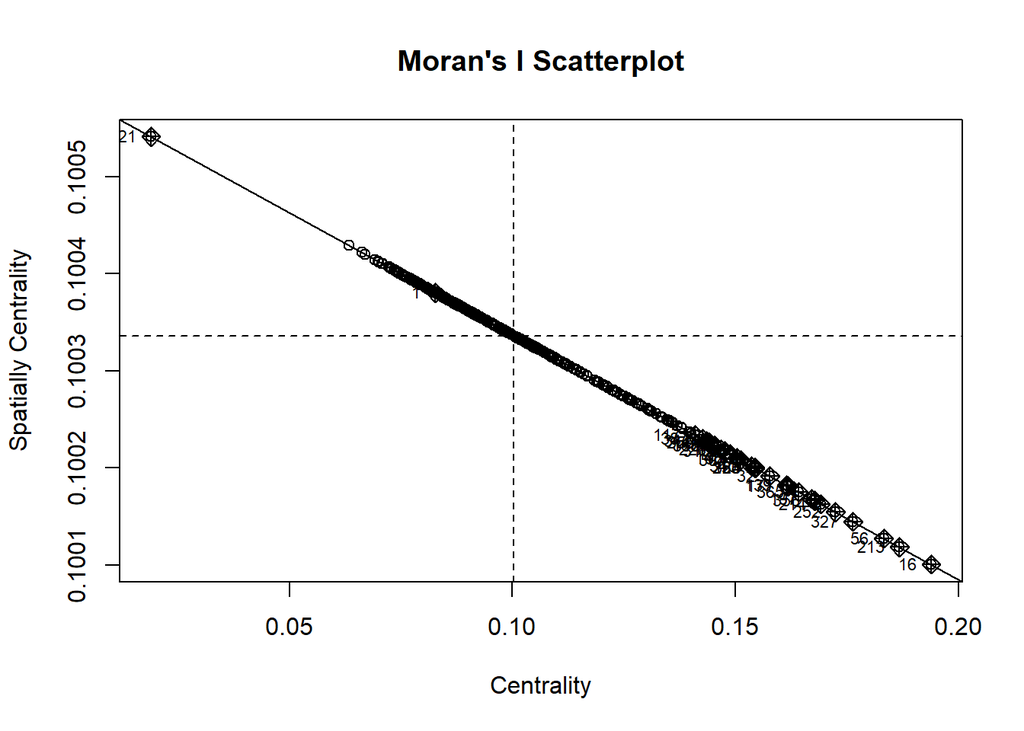

```r
moran.plot(
  all_stations$Centrality,
  w,
  main="Moran's I Scatterplot",
  xlab="Centrality",
  ylab="Spatially Centrality"
)
```

The whole plot can be divided into four quadrants: Upper right region (High-High, positive correlation): high centrality sites are surrounded by high centrality sites. Lower left region (Low-Low, positive correlation): low centrality sites are surrounded by low centrality sites. Upper left region (Low-High, negative correlation): low centrality sites are surrounded by high centrality sites. Lower right region(High-Low, negative correlation): high centrality sites surrounded by low centrality sites.

To government, this means that focusing control measures, such as health interventions or resource deployment, on specific geographic boroughs may not be effective. They need to take multiple high-centrality stations all over the network rather than just one or two primary hubs into consideration.